# Learning from Machines:

Differentiating US Presidential Campaigns with Attribution and Annotation

Musashi Jacobs-Harukawa

University of Oxford

Presented 19 May 2022 for Politics in Progress Colloquium (Oxford)

# Preamble

## tl;dr

- **Objective**: characterizing language of political actors.
- **Existing Tools**: summary via numerical reduction, theory-empirics link via lexical semantics.
- **Novel Method**: feature attribution on deep learning text classifiers.
- **Comparison and Validation**: application to US presidential FB campaigns.

## Useful Feedback

- Sufficiently motivated?
  - Is this a relevant question/task?
  - Would you want to use this tool?
- Structure of long-form presentation.
  - What parts to keep for a shorter version?
- Comments on framing very welcome
- Technical feedback also welcome

## Roadmap

1. Motivate and generalize task
2. Summarize existing tools
3. Introduce novel method
4. Application: US campaigns on Facebook
5. Comparison and validation

# Motivation

- Differentiating the language of political actors is a task of interest to empirical social science research.

## Characterization is Inference

[figure not shown]

Credit: BBC

## Differentiation as Characterization

[figure not shown]

Credit: BBC

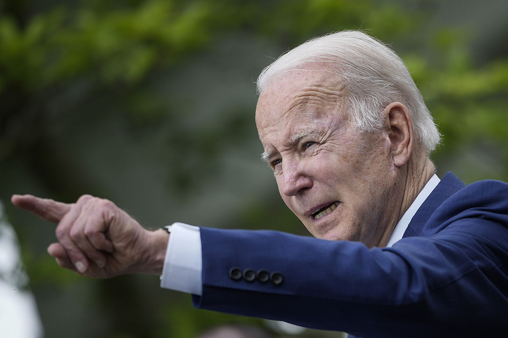

Credit: Politco

## Differentiation within Observations

*Trump or Biden?*

To all those who have been knocked down, counted out, left behind: This is your campaign.

Will you chip in $5 to help us turn to a new chapter in our nation’s history and defeat Donald Trump and Republicans down the ballot?

## Non-Trivial Differentiation

*Sanders or Warren*?

The Democrats are the party of big, structural change. We need to give people a reason to show up and vote. We must build a grassroots movement across this country, person by person, dollar by dollar.

## Recap: Task

- What features do ads from a campaign have in common?
- What features differentiate ads from different campaigns?

## Generalizing Further

Present application is campaigns, but could be framed:

- What features characterize language of a political actor?
- What features differentiate language of political actors?
- Judiciaries (Ovadek *forthcoming*[^1])
- Legislator Press Releases [@grimmer2013]

# Existing Tools

- Limits to existing text-as-data techniques result of two design decisions:
  - Outputs: numerical summary
  - Theoretical-empirical Link: lexical semantics
- Alternative tools desirable to explore other features,

## Tools for Language

- Language is complex
- Encoding of information in language is complex
- Models/methods needed to deal with this complexity

## QCA: Using Your Brain

- Human estimation of counts/proportions of concepts
- Overcomes structural complexity of language
- Lack of scalability

## Abundant Ads, Scalable Requirements

| Dataset | N Docs |
| --- | --- |
| Google Transparency (Politics, US) | 619K |
| Facebook Ad Library (Politics, US) | 13.3M |
| Princeton Corpus of Emails | 435K |
| ProPublica | 225K |

## Fightin’ Words [@monroe2008]

- Identify words that differentiate actors.
- Authors example: US legislators abortion debate.
  - Republican tokens: `kill`, `babi`, `procedur`
  - Democrat tokens: `woman`, `decis`, `famili`
- Can infer framing strategy [@chong2007]
- What about `mother`?

## Promises and Pitfalls of Text-as-Data

Tools for “*amplifying* and *augmenting* careful reading” [@grimmerstewart2013]

- “Amplifying”: scaling human reading
- “Augmenting”: supplementing human reading

## Text-as-Numbers

- Tabulating meaning for statistical models
- Common tasks/strategies:
  - Scaling speakers and documents with word frequencies
  - Decomposing DTM, modelling documents as mixture of semantic fields
  - Operationalizing meaning *P*(*w**o**r**d*|*c**o**n**t**e**x**t*) as input to statistical model

## Theoretical-Empirical Link

- General focus on *semantic* estimands.
- Modelled using *lexical semantics*.
- Theoretical-empirical link via meaning of words.
  - Substantive interpretation: word
  - Prevalence/existence: number/statistic

## Challenges

- Summaries → reductive → lossy.
- Word sense resolution difficult *sans context*.

## Another Way?

- Reductive statistical summary sometimes effective and appropriate
  - Especially if comparing counts/proportions of *meanings*.
- But!
  - Other kinds of linguistic phenomena exist.
  - Advantages to not disconnecting text and numerical summary.

# Novel Method

- Annotating a document with the feature attribution from a `BERT` model can reveal differentiating features.
- This method can be satisfactorily validated within empirical social science methodology.

## The Pitch

- Train `BERT`(-like) to classify ads by campaign.
- Ask `BERT` what the differentiating features are.
- Annotate source texts to highlight differentiating language.

## `BERT` [@devlin2019]

- Family of transformer-based sequence encoder architectures
  - *Sequence encoder*: text → sequence of vectors
- Excel at generating task-specific embeddings with minimal training.
  - *Task-specific embeddings*: numerical representation optimized to downstream application

## Explainability

- `BERT` and DL dominant in variety of empirical AI fields.
  - “Superhuman” accuracy on classification tasks [@storks2021]
- “Black Box”:
  - Large number of parameters (`BERT`-base has 110 million)
  - Intermediary weights have no straightforward interpretation.
- Interpretable ML subfield
  - Feature attribution

## Interrogating `BERT`

- Ask `BERT` which parts of the document inform its predictions.
  - Use feature attribution to get per-token scores.
  - Superimpose on text to see feature interactions.
- Why do this?
  - Experiments demonstrate some understanding of syntax [@lin2019], semantic relations [@ettinger2020]
  - Superhuman accuracy → may detect patterns humans do not.

## Feature Attribution

*Integrated Gradients* [@sundararajan2017]

- DL analog of decomposing OLS prediction into partial derivatives wrt inputs.
- +ve IG indicates feature “contributes” to +ve class
- -ve IG indicates feature “contributes” to -ve class
- 0 IG indicates no contribution
- Relative magnitudes matter, absolute hard to interpret.

## We Care About Validation

- Statistical: uncertainty measure of IG score
- Substantive: how can we be know high-IG tokens *matter*?
  - Compare to existing methods
  - Novel validation strategy

## Uncertainty for IG

*Monte Carlo Dropout* [@gal2016]

- Most DL architectures include random dropout layers.
- Can be used as computationally efficient bootstrap.
- I generate 30 draws, then bootstrap over these.

## Comparison to Existing Methods

*Fightin’ Words* [@monroe2008]

- Compare salience scores for log-odds (LO), Fightin’ Words (FW), and IG.
- High rank correlation good sign.
- But: divergence difficult to interpret.

## Empirical Sufficiency

Validation framework based on @jain2020 (FRESH)

1. Train classifier.
2. Use IG to extract high-salience regions (rationales).
3. Train two further models:
   - One only sees rationales
   - Other only sees text-sans-rationales.

## Sufficiency Strategy Summarized

| Model Trained | Model Accuracy | Strategy Precision | Strategy Recall |
| --- | --- | --- | --- |
| rationale | high | high | – |
| text-sans-rationale | low | – | high |

# Application

## Three Comparisons

| Comparsion | Purpose | N |
| --- | --- | --- |
| Trump vs Biden | Proof-of-concept, sense check | 527 |
| Sanders vs Warren | Difficult binary | 829 |
| 11 Democratic Primary | Multiclass | 3,165 |

## Pre/Post Processing, Training

- No lowercasing, stopword removal
- LO/FW pre-lemmatized, IG post-lemmatized for comparison
- `RoBERTa` byte-pair encoding subword tokenization
- Learning rates 3*e* − 4, 1*e* − 5 and 5*e* − 5
- All choices checked for implementation invariance

# Results

## Biden vs Trump

To all those who have been knocked down , counted out , left behind : This is your campaign . So whether you believed in me from the beginning or you just put your faith in me this week – I ’m grateful just the same . Will you chip in $ 5 to help us turn to a new chapter in our nation ’s history and defeat Donald Trump and Republicans down the ballot ?

## Biden vs Democratic Primary

To all those who have been knocked down , counted out , left behind : This is your campaign . So whether you believed in me from the beginning or you just put your faith in me this week – I ’m grateful just the same . Will you chip in $ 5 to help us turn to a new chapter in our nation ’s history and defeat Donald Trump and Republicans down the ballot ?

**Sanders vs Warren**

Medicare for All . College for All . Jobs for All . Justice For All . A government that works for ALL of us , and not just the wealthy few . If we ’re in this together , that ’s what we ’ll get . Can you make a donation to help power your campaign ?

**Sanders vs Rest**

Medicare for All . College for All . Jobs for All . Justice For All . A government that works for ALL of us , and not just the wealthy few . If we ’re in this together , that ’s what we ’ll get . Can you make a donation to help power your campaign ?

# Next Steps

- Software to make pipeline available to non-technical users
- Methodology for hybrid AI-augmented qualitative text analysis
- Further uses for model logic beyond annotation?

# References

[^1]: Michal Ovadek, Joshua Fjelstul, Daniel Naurin, Johan Lindholm. “Predicting Authorship at the Court of Justice of the European Union.” *Working paper*.